# ICA 20, 21, 23

Create separate models for the 3 species. How do the models compare, in terms of errors and coefficients? Which of the models are similar to each other (if at all)?

```r
mods <- list()

spec <- c("Adelie", "Chinstrap", "Gentoo")
for(i in 1:3){
  sset <- subset(penguin, subset = species == spec[i])
  mods[[i]] <- lm(data = sset, body_mass_g ~ bill_length_mm)
}
summary(mods[[1]])
```

[output not shown]

Which model is the “best?” Why?

STT 380 In-Class Assignment 25 For the pizza dataset, Build a linear regression model for calories, based on fat.

```r
pizza <- read.csv('pizza.csv')
head(pizza)
summary(lm(data = pizza, cal ~ fat))
```

[output not shown]

How does the RMSE compare to that for the naïve model? Now, add moisture to the model. Has the model significantly improved? How can you tell?

```r
summary(lm(data = pizza, cal ~ fat + mois))
```

[output not shown]

Now, add sodium to the model from (c). Has the model significantly improved? How can you tell?

```r
summary(lm(data = pizza, cal ~ fat + mois + sodium))
```

[output not shown]

For the cars dataset, build a model to predict mpg based on acceleration. Build a confidence interval for the acceleration parameter based on t values Build a confidence interval for the acceleration parameter based on regular bootstrapping Build a confidence interval for the acceleration parameter based on Bayesian bootstrapping How do the CI’s compare? Build a linear regression model, using acceleration and weight to predict mpg. Perform sensitivity analysis to determine the impact of each x variable on the model.

STT 380 In-Class Assignment 26

For this we will look at the economic data provided. We will use the other variables to predict consumer sentiment. The other variables are unemployment rate Create a cross-correlation plot for each x against the consumer sentiment data (undifferenced). Which lag (to the right of 0) for each appears to be the most useful (don’t use past lag 12)? (Be sure to use the correct sign of correlation!)

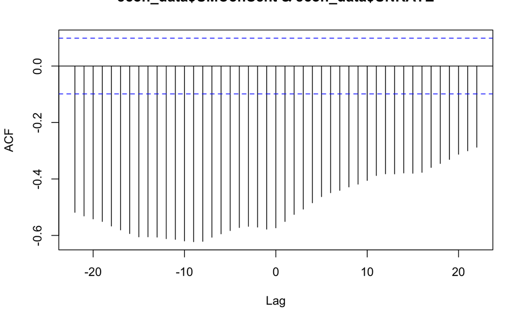

```r
econ_data <- read.csv('econ_data.csv')

ccf(econ_data$UMConSent, econ_data$UNRATE)
```

```r
#econ_data
```

one

Built a lm model based on these lagged x’s.

```r
summary(lm(econ_data$UMConSent~lag(UNRATE$..0.377,6)))
```

```
Error in lag(UNRATE$..0.377, 6) : object 'UNRATE' not found
```

Based on your model, what is the prediction for November 2022?

New, create a cross-correlation plot for each x against the consumer sentiment data, but this time, with differenced data.  
Which positive lag for each appears to be the most useful? Built a lm model based on the differenced results. How does the model compare to that of (2) in terms of both R-squared and RMSE?

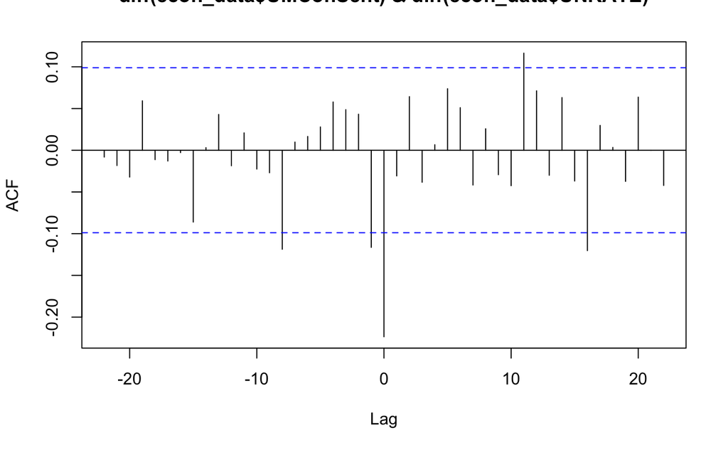

```r
ccf(diff(econ_data$UMConSent),diff(econ_data$UNRATE))
```